# Regressao

### Criando os intervalos de confiança, erro

-Aqui montamos intervalos de confiança para um melhor entendimento do modelo, com 95% dew confiança e para 99% de confiança.

**95%** de confiança

```r
intervalo_conf = dados_carros %>%
  mutate(erro = abs(dados_carros$Price - dados_carros$pred_mod_vw)) %>%
  summarise(erro_i = quantile(erro, .01),
            erro_s = quantile(erro, .95)) %>%
  mutate(valor_i = mean(dados_carros$Price) + erro_i,
         valor_s = mean(dados_carros$Price) + erro_s)
intervalo_conf
```

| erro_i | erro_s | valor_i | valor_s |
| --- | --- | --- | --- |
| 135.4688 | 18637.2 | 21301.55 | 39803.28 |

**99%** de confiança

```r
intervalo_conf_99 = dados_carros %>%
  mutate(erro = abs(dados_carros$Price - dados_carros$pred_mod_vw)) %>%
  summarise(erro_i = quantile(erro, .01),
            erro_s = quantile(erro, .99)) %>%
  mutate(valor_i = mean(dados_carros$Price) + erro_i,
         valor_s = mean(dados_carros$Price) + erro_s)
intervalo_conf_99
```

| erro_i | erro_s | valor_i | valor_s |
| --- | --- | --- | --- |
| 135.4688 | 33362.92 | 21301.55 | 54528.99 |

### Gráfico Intervalo de confiança

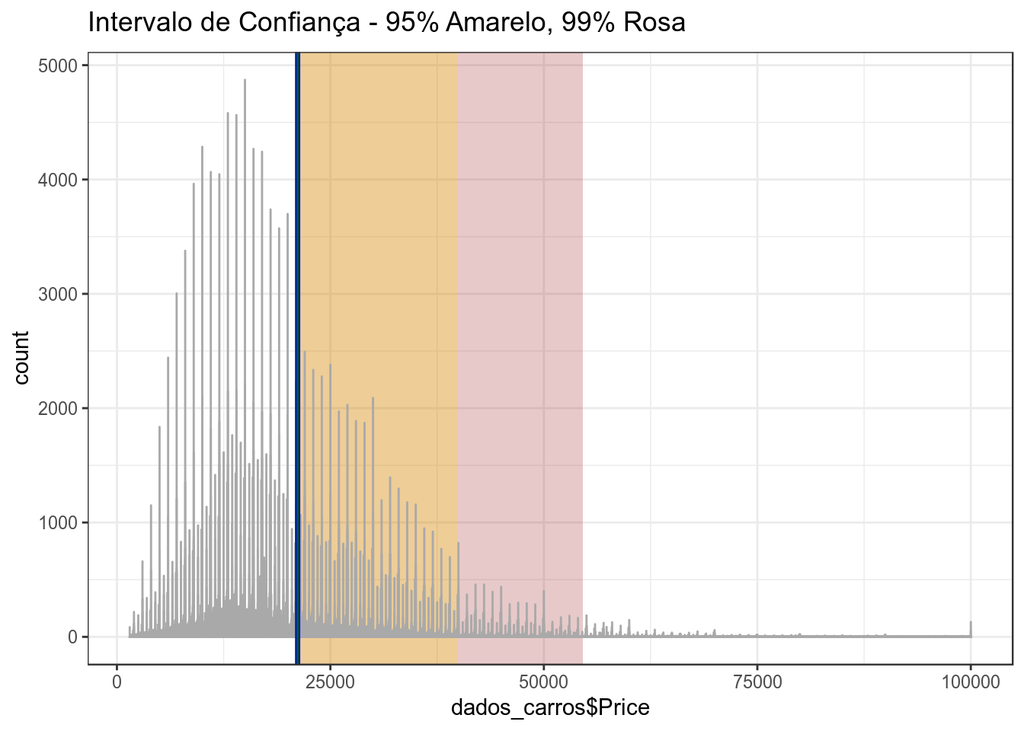

```r
ggplot() +
  geom_rect(
    data = intervalo_conf_99,
    aes(xmin = valor_i, xmax = valor_s),
    ymin = -Inf,
    ymax = Inf,
    fill = "brown",
    alpha = .25
  ) +
  geom_rect(
    data = intervalo_conf,
    aes(xmin = valor_i, xmax = valor_s),
    ymin = -Inf,
    ymax = Inf,
    fill = "gold",
    alpha = .25
  ) +
  geom_histogram(
    data = dados_carros,
    aes(dados_carros$Price),
    binwidth = .5,
    fill = "white",
    colour = "darkgrey"
  ) +
  geom_vline(xintercept = mean(dados_carros$Price),
             color = "blue",
             size = 1.2) +
  geom_vline(xintercept = mean(dados_carros$Price), color = "dark green") +
  labs(title = expression("Intervalo de Confiança - 95% Amarelo, 99% Rosa",x = "Preço dos carros em $",
       y = "Número de carros com o preço"))
```

## Analisando por meio de estatítiscas

Uma maneira de mostrar que o modelo adotado realmente condiz com a realidade é analisando os erros residuais que a mesma tem. Uma forma estatística bastante difundida para mostrar a integridade do dado é a análise do **R²** que é o coeficiente de determinação que segundo a Wikipedia é " é uma medida de ajustamento de um modelo estatístico linear generalizado, como a regressão linear, em relação aos valores observados“. O valor de **R²** varia entre 0 e 1. Sendo que mais próximo de 1, mais existem evidências do modelo conseguir explicar os valores observados. Nosso **R²** pode ser visto na tabela abaixo:

```r
# variância de y
var.y2 <- sum((dados_carros$Price - mean(dados_carros$Price))^2)
# variância dos resíduos do modelo
var.residuals <- sum(modelo_geral$residuals^2)

#calculando e conferindo o R^2
(var.y2 - var.residuals)/var.y2
```

```
## [1] 0.2473829
```

```r
rsquare(modelo_geral, data = dados_carros)
```

```
## [1] 0.2473829
```

```r
glance(modelo_geral)
```

| r.squared | adj.r.squared | sigma | statistic | p.value | df | logLik | AIC | BIC | deviance | df.residual |
| --- | --- | --- | --- | --- | --- | --- | --- | --- | --- | --- |
| 0.2473829 | 0.2473812 | 10038.96 | 139471.2 | 0 | 3 | -9023666 | 18047340 | 18047387 | 85525725150426 | 848631 |

Nosso **R²** é 0.2473829. O que indica que esse modelo não possui bons sinais que explicam a regressão, Outras medidas que podem ser utilizadas para a análise são o: - MAE: Erro médio absolutos - RMSE: Raiz do erro quadrático médio

```r
mae(modelo_geral, dados_carros)
```

```
## [1] 7493.289
```

```r
rmse(modelo_geral, dados_carros)
```

```
## [1] 10038.95
```